# PHH_EG

Sem

2025-05-06

```r
library(ggplot2)
library(dplyr)
data_dir <- "C:/Users/semde/Universiteit Leiden/BOO 2025 - BOO CDS Giulia team - BOO CDS Giulia team/3_Data/Sem/PHH_TXG-MAPr"
expression_long   <- readRDS(file.path(data_dir, "expression_long.rds"))
module_definition        <- readRDS(file.path(data_dir, "module_definition.rds"))
eg_score          <- readRDS(file.path(data_dir, "eg_score.rds"))
module_annotation <- readRDS(file.path(data_dir, "module_annotation.rds"))
```

# Distribution of Log2FC and adjusted p-value

## Log2FC

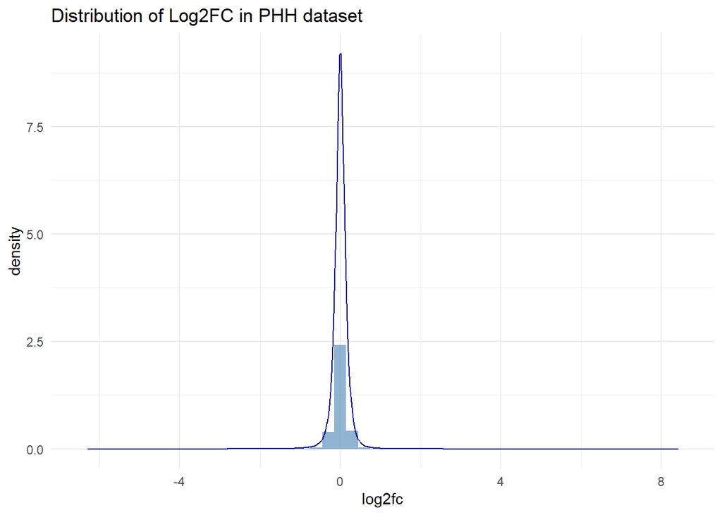

```r
ggplot(expression_long, aes(x = log2fc)) +
  geom_histogram(aes(y = ..density..), bins = 50, fill = "steelblue", alpha = 0.6) +
  geom_density(color = "darkblue") +
  theme_minimal() + labs(title = "Distribution of Log2FC in PHH dataset")
```

```r
sum(abs(expression_long$log2fc) > 1)
```

```
## [1] 77639
```

## p-adjusted

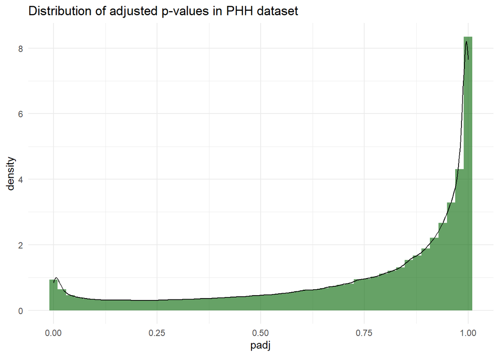

```r
ggplot(expression_long, aes(x = padj)) +
  geom_histogram(aes(y = ..density..), bins = 50, fill = "darkgreen", alpha = 0.6) +
  geom_density(color = "black") +
  theme_minimal() +
  labs(title = "Distribution of adjusted p-values in PHH dataset")
```

```r
sum(expression_long$padj <  0.05)
```

```
## [1] 674354
```

## Both Log2FC and padj significant

```r
sum(abs(expression_long$log2fc) > 1 & expression_long$padj < 0.05)
```

```
## [1] 76111
```

# Gene Response Rate

The proposed Gene Response Rate reflects the total of significant genes (abs(Log2FC) > 1.0 & padj < 0.05) in a module with size n. This will be plotted against the eigengene score to assess this scoring method.

$$GRR = \frac{ \displaystyle \sum_{i=1}^{n} \left( |\log_2 \mathrm{FC}_i|
> 1.0 \ \land \ p_{\mathrm{adj},i} < 0.05 \right) }{ n }$$
## Merge module_definition with expression_long

```r
# Add the modules to the genes in expression_long, don't join with all the variabels -> saves memory

expression_with_module <- expression_long %>%
  select(entrez_id, sample_id, log2fc, padj) %>%
  inner_join(
    module_definition %>% select(entrez_id, module_number, module_size),
    by = "entrez_id"
  ) %>%
  filter(module_number != 0) # Module 0 is irrelevant so delete
```

## Calculate significant genes and total per module

```r
# Calculate significant genes
expression_with_module <- expression_with_module %>%
  mutate(significant = abs(log2fc) > 1 & padj < 0.05)


# Count significant genes per module
sig_count <- expression_with_module %>%
  group_by(module_number, sample_id) %>%
  summarise(sig_genes = sum(significant), .groups = "drop")
```

## Add the module_size to sig_count and calculate GRR

```r
sig_count <- sig_count %>%
  left_join(
    expression_with_module %>%
      distinct(module_number, module_size),
    by = "module_number"
  )
```

```r
sig_count <- sig_count %>%
  mutate(GRR = sig_genes / module_size)
```

## Join GRR with EG score per sample

```r
GRR_vs_eg_score <- sig_count %>%
  inner_join(eg_score, by = c("module_number", "sample_id"))
```

## Density plots of GRR and EG score

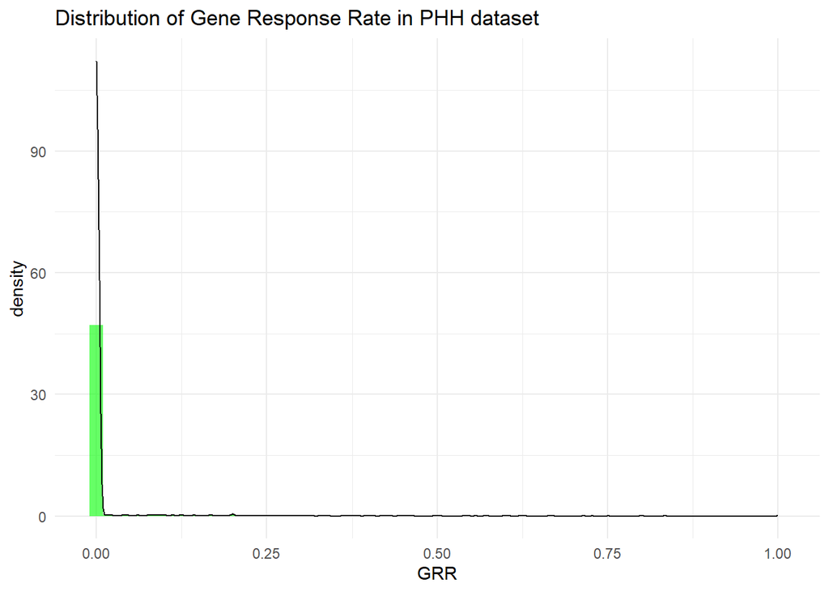

```r
ggplot(GRR_vs_eg_score, aes(x = GRR)) +
  geom_histogram(aes(y = ..density..), bins = 50, fill = "green", alpha = 0.6) +
  geom_density(color = "black") +
  theme_minimal() + labs(title = "Distribution of Gene Response Rate in PHH dataset")
```

Like expected, the GRR shows a logaritmic distribution due to the count data nature.

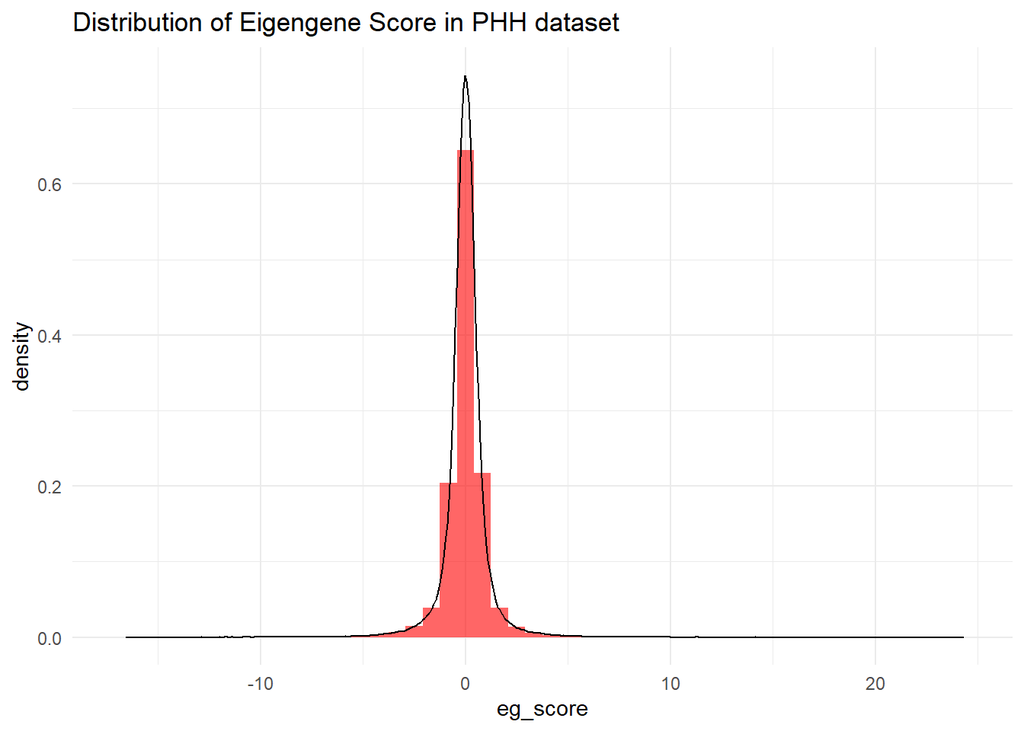

```r
ggplot(GRR_vs_eg_score, aes(x = eg_score)) +
  geom_histogram(aes(y = ..density..), bins = 50, fill = "red", alpha = 0.6) +
  geom_density(color = "black") +
  theme_minimal() + labs(title = "Distribution of Eigengene Score in PHH dataset")
```

Eigengene shows a normal distribution, as expected due to the PCA use.

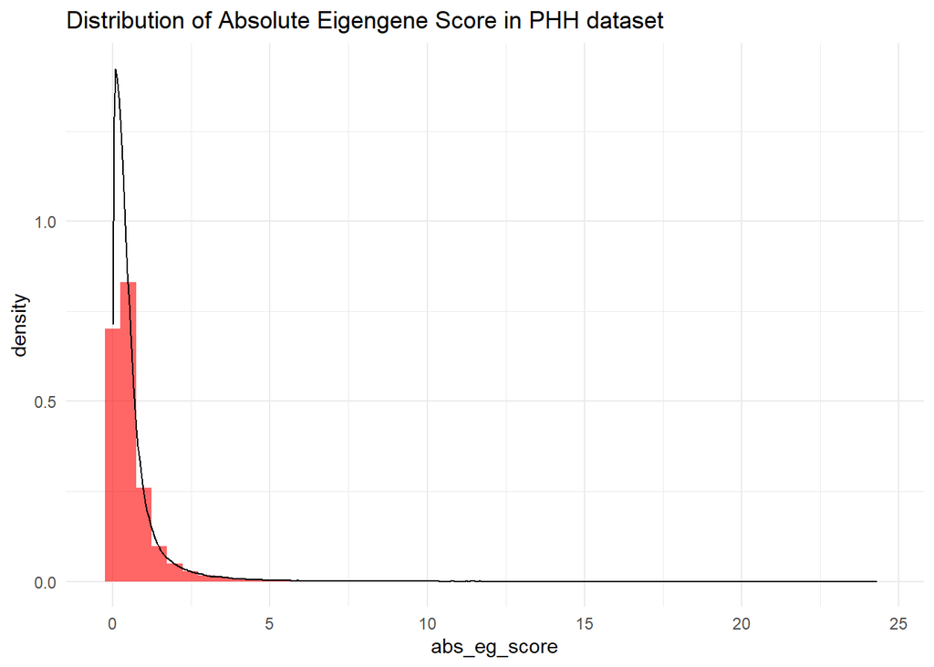

```r
ggplot(GRR_vs_eg_score, aes(x = abs_eg_score)) +
  geom_histogram(aes(y = ..density..), bins = 50, fill = "red", alpha = 0.6) +
  geom_density(color = "black") +
  theme_minimal() + labs(title = "Distribution of Absolute Eigengene Score in PHH dataset")
```

## Visualize GRR vs EG score with a linear fit

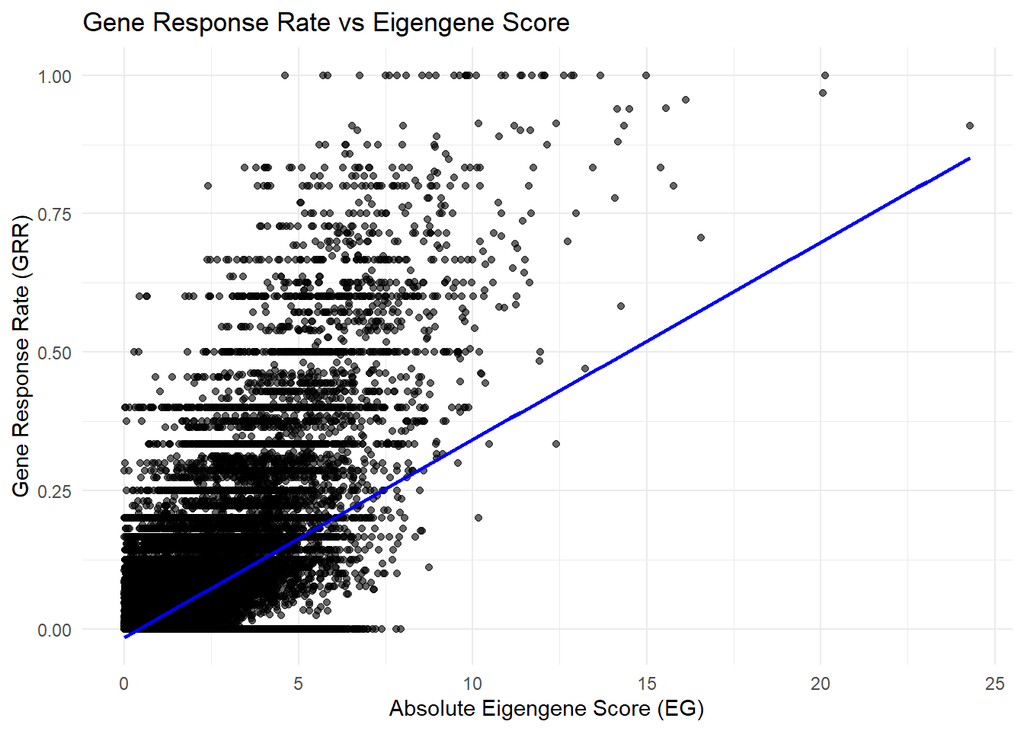

```r
ggplot(GRR_vs_eg_score, aes(x = abs_eg_score, y = GRR)) +
  geom_point(alpha = 0.6) +
  geom_smooth(method = "lm", se = FALSE, color = "blue") +
  theme_minimal() +
  labs(
    title = "Gene Response Rate vs Eigengene Score",
    x = "Absolute Eigengene Score (EG)",
    y = "Gene Response Rate (GRR)"
  )
```

The linear fit does not follow the trend of the GRR vs EG, as expected due to the logarithmic distribution of the GRR. Next we will try to fit a different, logarthmic fit. To detect significant outliers.

## Binomial Generalized Linear Model (GLM)

```r
glm_fit <- glm(
  cbind(sig_genes, module_size - sig_genes) ~ abs_eg_score,
  family = binomial(link = "logit"),
  data = GRR_vs_eg_score
)
```

```r
# Make predictions and residuals
glm_predictions <- predict(glm_fit, type = "response")
glm_dev_resid <- residuals(glm_fit, type = "deviance")

# Combine into a new dataframe
GRR_glm_fit_df <- GRR_vs_eg_score %>%
  mutate(
    fitted_prob = glm_predictions,
    fitted_sig_genes = fitted_prob * module_size,
    residual = sig_genes - fitted_sig_genes,
    dev_resid = glm_dev_resid
  )
```

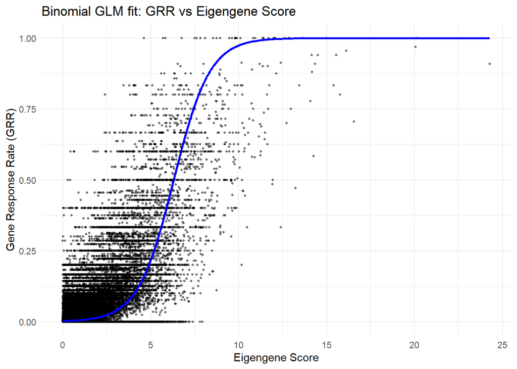

```r
ggplot(GRR_glm_fit_df, aes(x = abs_eg_score, y = GRR)) +
  geom_point(alpha = 0.5, size = 0.8) +
  geom_line(aes(y = fitted_sig_genes / module_size), color = "blue", size = 1) +
  theme_minimal() +
  labs(
    title = "Binomial GLM fit: GRR vs Eigengene Score",
    x = "Eigengene Score",
    y = "Gene Response Rate (GRR)"
  )
```

```r
summary(glm_fit)
```

```
##
## Call:
## glm(formula = cbind(sig_genes, module_size - sig_genes) ~ abs_eg_score,
##     family = binomial(link = "logit"), data = GRR_vs_eg_score)
##
## Coefficients:
##               Estimate Std. Error z value Pr(>|z|)
## (Intercept)  -6.171894   0.006081   -1015   <2e-16 ***
## abs_eg_score  0.978054   0.001941     504   <2e-16 ***
## ---
## Signif. codes:  0 '***' 0.001 '**' 0.01 '*' 0.05 '.' 0.1 ' ' 1
##
## (Dispersion parameter for binomial family taken to be 1)
##
##     Null deviance: 430962  on 374517  degrees of freedom
## Residual deviance: 180412  on 374516  degrees of freedom
## AIC: 219493
##
## Number of Fisher Scoring iterations: 7
```

```r
deviance(glm_fit) / df.residual(glm_fit)
```

```
## [1] 0.4817193
```

```r
1 - (glm_fit$deviance / glm_fit$null.deviance)
```

```
## [1] 0.5813746
```

### significant outliers

For each module and sample, we compare the observed number of significant genes to the expected number based on the binomial GLM, and calculate a two-sided z-score and p-value using the binomial standard error. By doing this, the significant outlying modules from the glm fit are identified.

```r
GRR_glm_fit_df <- GRR_glm_fit_df %>%
  mutate(
    se_fit = sqrt(module_size * fitted_prob * (1 - fitted_prob)),
    z_score = (sig_genes - fitted_sig_genes) / se_fit,
    p_value = 2 * pnorm(-abs(z_score))  # two-sided test
  )
```

```r
GRR_glm_fit_df <- GRR_glm_fit_df %>%
  mutate(outlier = p_value < 0.05)
```

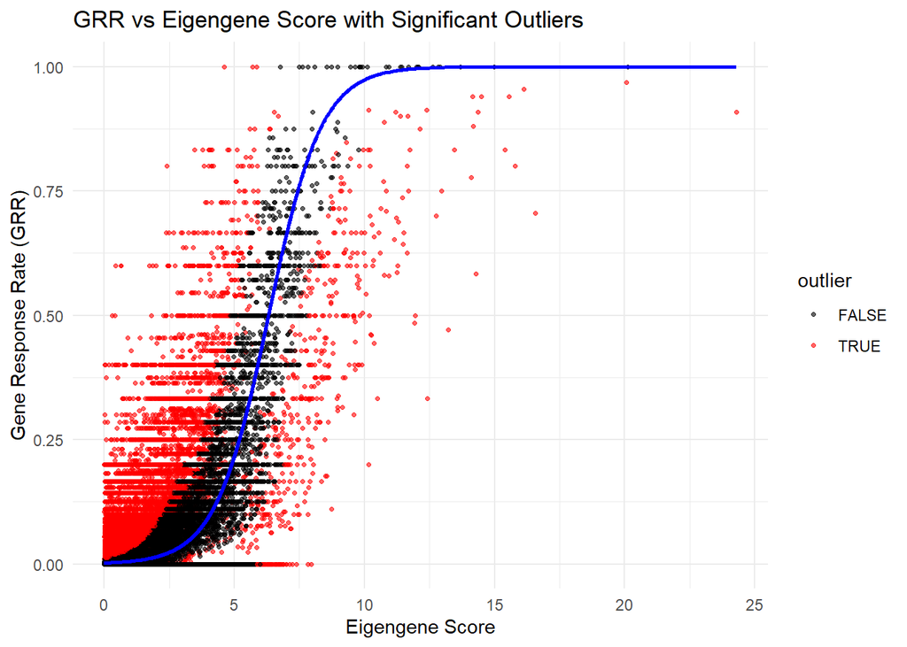

```r
ggplot(GRR_glm_fit_df, aes(x = abs_eg_score, y = GRR)) +
  geom_point(aes(color = outlier), alpha = 0.6, size = 0.9) +
  geom_line(aes(y = fitted_sig_genes / module_size), color = "blue", size = 1) +
  scale_color_manual(values = c("black", "red")) +
  theme_minimal() +
  labs(
    title = "GRR vs Eigengene Score with Significant Outliers",
    x = "Eigengene Score",
    y = "Gene Response Rate (GRR)"
  )
```

## Modules and conditions with most significant outliers’

Based on the binomial GLM fit, we will now find the modules and conditions with the most significant outliers and with an abs eg_score > 2.0

```r
significant_outliers_filtered <- GRR_glm_fit_df %>%
  filter(outlier, abs(eg_score) > 2)
```

```r
outliers_per_module <- significant_outliers_filtered %>%
  count(module_number, sort = TRUE)
```

```r
outliers_per_sample <- significant_outliers_filtered %>%
  count(sample_id, sort = TRUE)
```

```r
head(outliers_per_module, 10) # Top modules with outliers
```

```
## # A tibble: 10 × 2
##    module_number     n
##            <dbl> <int>
##  1           295    62
##  2             1    57
##  3            86    54
##  4            15    50
##  5           134    50
##  6             4    47
##  7            11    47
##  8           112    45
##  9           340    45
## 10            44    43
```

```r
head(outliers_per_sample, 10) # Top cconditions with outliers
```

```
## # A tibble: 10 × 2
##    sample_id                                    n
##    <chr>                                    <int>
##  1 TG_HPHH_SINGLE_CYCLOHEXIMIDE_T3_C3         119
##  2 TG_HPHH_SINGLE_ETHIONINE_T3_C3              93
##  3 TG_HPHH_SINGLE_DOXORUBICIN_T3_C3            81
##  4 TG_HPHH_SINGLE_CYCLOHEXIMIDE_T3_C2          74
##  5 TG_HPHH_SINGLE_BROMOETHYLAMINE_T3_C3        71
##  6 TG_HPHH_SINGLE_THEOPHYLLINE_T3_C3           63
##  7 TG_HPHH_SINGLE_NMETHYLNNITROSOUREA_T3_C3    62
##  8 TG_HPHH_SINGLE_SULINDAC_T3_C3               62
##  9 TG_HPHH_SINGLE_COLCHICINE_T3_C3             58
## 10 TG_HPHH_SINGLE_PHENOBARBITAL_T3_C3          56
```

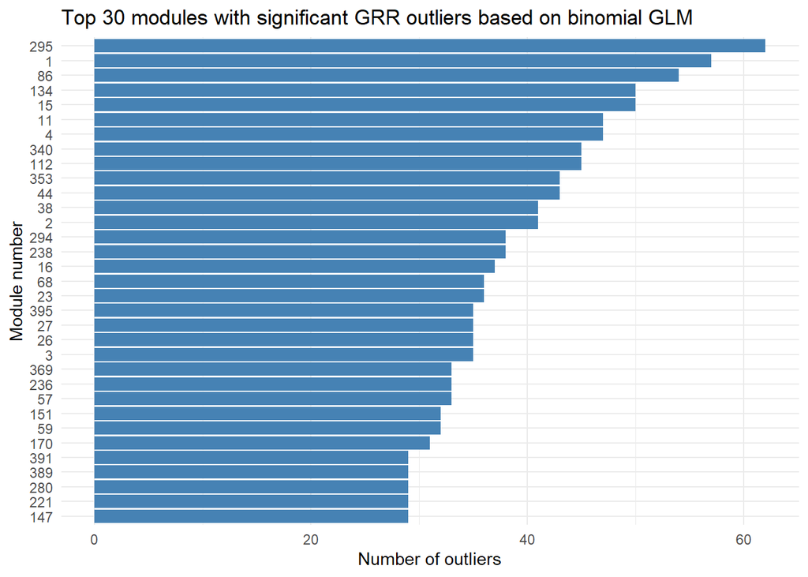

```r
outliers_per_module %>%
  top_n(30, n) %>%  # Top 30 modules
  ggplot(aes(x = reorder(as.factor(module_number), n), y = n)) +
  geom_col(fill = "steelblue") +
  coord_flip() +
  theme_minimal() +
  labs(title = "Top 30 modules with significant GRR outliers based on binomial GLM",
       x = "Module number",
       y = "Number of outliers")
```

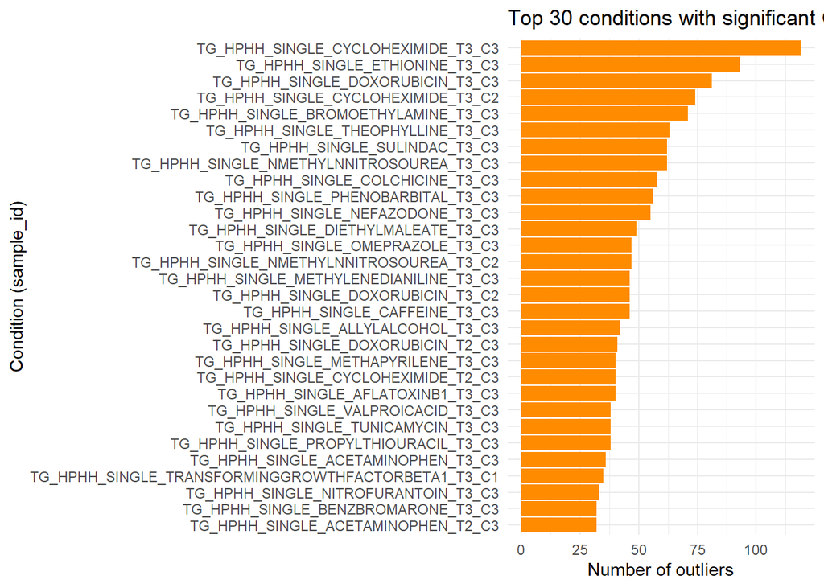

```r
outliers_per_sample %>%
  top_n(30, n) %>%  # Top 30 conditions
  ggplot(aes(x = reorder(sample_id, n), y = n)) +
  geom_col(fill = "darkorange") +
  coord_flip() +
  theme_minimal() +
  labs(title = "Top 30 conditions with significant GRR outliers",
       x = "Condition (sample_id)",
       y = "Number of outliers")
```

## Modules with most significant outliers based on binomial GLM and annotation (human)

```r
outliers_per_module <- outliers_per_module %>%
  mutate(module = paste0("hPHH_", module_number))
```

```r
outliers_annotated <- outliers_per_module %>%
  inner_join(module_annotation, by = "module")
```

```r
outliers_annotated %>%
  arrange(desc(n)) %>%
  head(20)
```

```
## # A tibble: 20 × 4
##    module_number     n module   annotation
##            <dbl> <int> <chr>    <chr>
##  1           295    62 hPHH_295 Stress response, ER stress, ATF4
##  2             1    57 hPHH_1   Cell cycle
##  3            86    54 hPHH_86  Signaling, TGFb
##  4            15    50 hPHH_15  Stress response, ER stress, ATF4
##  5           134    50 hPHH_134 Metabolism, xenobiotic
##  6             4    47 hPHH_4   Transcription
##  7            11    47 hPHH_11  Metabolism
##  8           112    45 hPHH_112 <NA>
##  9           340    45 hPHH_340 Metabolism, fatty acid
## 10            44    43 hPHH_44  Immune response, NFkB
## 11           353    43 hPHH_353 <NA>
## 12             2    41 hPHH_2   Mitochondrion
## 13            38    41 hPHH_38  Metabolism, bile acid
## 14           238    38 hPHH_238 Metabolism, bile acid
## 15           294    38 hPHH_294 <NA>
## 16            16    37 hPHH_16  Metabolism, cholesterol
## 17            23    36 hPHH_23  Immune response, complement
## 18            68    36 hPHH_68  <NA>
## 19             3    35 hPHH_3   Signaling, transmembrane
## 20            26    35 hPHH_26  Immune response, NFkB
```

Above shows the top modules with significant outliers from the GLM fit including annotation.

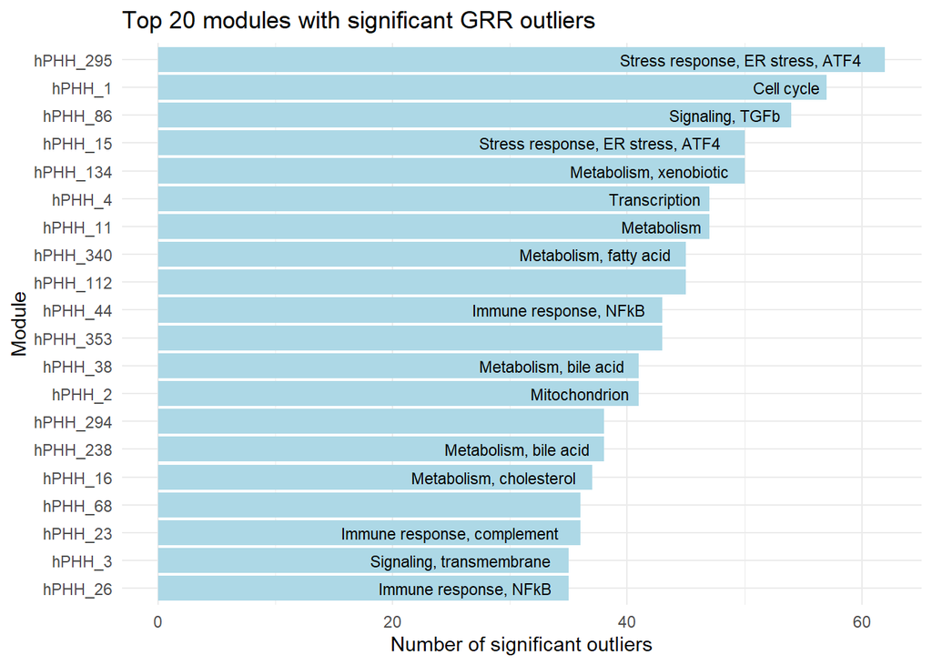

```r
outliers_annotated %>%
  arrange(desc(n)) %>%
  slice_head(n = 20) %>%
  ggplot(aes(x = reorder(module, n), y = n)) +
  geom_col(fill = "lightblue") +
  geom_text(aes(label = annotation), hjust = 1.1, color = "black", size = 3) +
  coord_flip() +
  theme_minimal() +
  labs(
    title = "Top 20 modules with significant GRR outliers",
    x = "Module",
    y = "Number of significant outliers"
  )
```